# Risk Factor Analysis

## Outcome Variable

**Outcome Variable:** whz

## Predictor Variables

**Intervention Variable:** birthlen

**Adjustment Set:**

- arm
- sex
- W_mage
- meducyrs
- feducyrs
- vagbrth
- single
- W_nrooms
- brthmon
- W_parity
- impsan
- delta_W_mage
- delta_meducyrs
- delta_feducyrs
- delta_vagbrth
- delta_single
- delta_W_nrooms
- delta_brthmon
- delta_W_parity
- delta_impsan

## Stratifying Variables

The analysis was stratified on these variable(s):

- agecat
- studyid
- country

## Data Summary

| agecat | studyid | country | birthlen | n_cell | n |
| --- | --- | --- | --- | --- | --- |
| Birth | ki0047075b-MAL-ED | BANGLADESH | >=50 cm | 39 | 215 |
| Birth | ki0047075b-MAL-ED | BANGLADESH | <48 cm | 97 | 215 |
| Birth | ki0047075b-MAL-ED | BANGLADESH | [48-50) cm | 79 | 215 |
| Birth | ki0047075b-MAL-ED | BRAZIL | >=50 cm | 30 | 62 |
| Birth | ki0047075b-MAL-ED | BRAZIL | <48 cm | 14 | 62 |
| Birth | ki0047075b-MAL-ED | BRAZIL | [48-50) cm | 18 | 62 |
| Birth | ki0047075b-MAL-ED | INDIA | >=50 cm | 9 | 45 |
| Birth | ki0047075b-MAL-ED | INDIA | <48 cm | 18 | 45 |
| Birth | ki0047075b-MAL-ED | INDIA | [48-50) cm | 18 | 45 |
| Birth | ki0047075b-MAL-ED | NEPAL | >=50 cm | 8 | 26 |
| Birth | ki0047075b-MAL-ED | NEPAL | <48 cm | 11 | 26 |
| Birth | ki0047075b-MAL-ED | NEPAL | [48-50) cm | 7 | 26 |
| Birth | ki0047075b-MAL-ED | PERU | >=50 cm | 52 | 228 |
| Birth | ki0047075b-MAL-ED | PERU | <48 cm | 83 | 228 |
| Birth | ki0047075b-MAL-ED | PERU | [48-50) cm | 93 | 228 |
| Birth | ki0047075b-MAL-ED | SOUTH AFRICA | >=50 cm | 43 | 120 |
| Birth | ki0047075b-MAL-ED | SOUTH AFRICA | <48 cm | 31 | 120 |
| Birth | ki0047075b-MAL-ED | SOUTH AFRICA | [48-50) cm | 46 | 120 |
| Birth | ki0047075b-MAL-ED | TANZANIA, UNITED REPUBLIC OF | >=50 cm | 32 | 115 |
| Birth | ki0047075b-MAL-ED | TANZANIA, UNITED REPUBLIC OF | <48 cm | 32 | 115 |
| Birth | ki0047075b-MAL-ED | TANZANIA, UNITED REPUBLIC OF | [48-50) cm | 51 | 115 |
| Birth | ki1000108-CMC-V-BCS-2002 | INDIA | >=50 cm | 13 | 86 |
| Birth | ki1000108-CMC-V-BCS-2002 | INDIA | <48 cm | 33 | 86 |
| Birth | ki1000108-CMC-V-BCS-2002 | INDIA | [48-50) cm | 40 | 86 |
| Birth | ki1000108-IRC | INDIA | >=50 cm | 120 | 343 |
| Birth | ki1000108-IRC | INDIA | <48 cm | 87 | 343 |
| Birth | ki1000108-IRC | INDIA | [48-50) cm | 136 | 343 |
| Birth | ki1000109-EE | PAKISTAN | >=50 cm | 21 | 177 |
| Birth | ki1000109-EE | PAKISTAN | <48 cm | 102 | 177 |
| Birth | ki1000109-EE | PAKISTAN | [48-50) cm | 54 | 177 |

[output cut: 198 more lines]

The following strata were considered:

- agecat: 24 months, studyid: ki0047075b-MAL-ED, country: BANGLADESH
- agecat: 24 months, studyid: ki0047075b-MAL-ED, country: BRAZIL
- agecat: 24 months, studyid: ki0047075b-MAL-ED, country: INDIA
- agecat: 24 months, studyid: ki0047075b-MAL-ED, country: NEPAL
- agecat: 24 months, studyid: ki0047075b-MAL-ED, country: PERU
- agecat: 24 months, studyid: ki0047075b-MAL-ED, country: SOUTH AFRICA
- agecat: 24 months, studyid: ki0047075b-MAL-ED, country: TANZANIA, UNITED REPUBLIC OF
- agecat: 24 months, studyid: ki1000108-CMC-V-BCS-2002, country: INDIA
- agecat: 24 months, studyid: ki1000108-IRC, country: INDIA
- agecat: 24 months, studyid: ki1000109-EE, country: PAKISTAN
- agecat: 24 months, studyid: ki1017093-NIH-Birth, country: BANGLADESH
- agecat: 24 months, studyid: ki1017093b-PROVIDE, country: BANGLADESH
- agecat: 24 months, studyid: ki1017093c-NIH-Crypto, country: BANGLADESH
- agecat: 24 months, studyid: ki1101329-Keneba, country: GAMBIA
- agecat: 24 months, studyid: ki1113344-GMS-Nepal, country: NEPAL
- agecat: 24 months, studyid: ki1114097-CMIN, country: BANGLADESH
- agecat: 24 months, studyid: ki1114097-CONTENT, country: PERU
- agecat: 24 months, studyid: ki1119695-PROBIT, country: BELARUS
- agecat: 24 months, studyid: ki1126311-ZVITAMBO, country: ZIMBABWE
- agecat: 24 months, studyid: ki1135781-COHORTS, country: GUATEMALA
- agecat: 24 months, studyid: ki1135781-COHORTS, country: INDIA
- agecat: 24 months, studyid: ki1135781-COHORTS, country: PHILIPPINES
- agecat: 24 months, studyid: kiGH5241-JiVitA-3, country: BANGLADESH
- agecat: 24 months, studyid: kiGH5241-JiVitA-4, country: BANGLADESH
- agecat: 6 months, studyid: ki0047075b-MAL-ED, country: BANGLADESH
- agecat: 6 months, studyid: ki0047075b-MAL-ED, country: BRAZIL
- agecat: 6 months, studyid: ki0047075b-MAL-ED, country: INDIA
- agecat: 6 months, studyid: ki0047075b-MAL-ED, country: NEPAL
- agecat: 6 months, studyid: ki0047075b-MAL-ED, country: PERU
- agecat: 6 months, studyid: ki0047075b-MAL-ED, country: SOUTH AFRICA
- agecat: 6 months, studyid: ki0047075b-MAL-ED, country: TANZANIA, UNITED REPUBLIC OF
- agecat: 6 months, studyid: ki1000108-CMC-V-BCS-2002, country: INDIA
- agecat: 6 months, studyid: ki1000108-IRC, country: INDIA
- agecat: 6 months, studyid: ki1000109-EE, country: PAKISTAN
- agecat: 6 months, studyid: ki1000109-ResPak, country: PAKISTAN
- agecat: 6 months, studyid: ki1000304b-SAS-CompFeed, country: INDIA
- agecat: 6 months, studyid: ki1017093-NIH-Birth, country: BANGLADESH
- agecat: 6 months, studyid: ki1017093b-PROVIDE, country: BANGLADESH
- agecat: 6 months, studyid: ki1017093c-NIH-Crypto, country: BANGLADESH
- agecat: 6 months, studyid: ki1101329-Keneba, country: GAMBIA
- agecat: 6 months, studyid: ki1113344-GMS-Nepal, country: NEPAL
- agecat: 6 months, studyid: ki1114097-CMIN, country: BANGLADESH
- agecat: 6 months, studyid: ki1114097-CONTENT, country: PERU
- agecat: 6 months, studyid: ki1119695-PROBIT, country: BELARUS
- agecat: 6 months, studyid: ki1126311-ZVITAMBO, country: ZIMBABWE
- agecat: 6 months, studyid: ki1135781-COHORTS, country: GUATEMALA
- agecat: 6 months, studyid: ki1135781-COHORTS, country: INDIA
- agecat: 6 months, studyid: ki1135781-COHORTS, country: PHILIPPINES
- agecat: 6 months, studyid: kiGH5241-JiVitA-3, country: BANGLADESH
- agecat: 6 months, studyid: kiGH5241-JiVitA-4, country: BANGLADESH
- agecat: Birth, studyid: ki0047075b-MAL-ED, country: BANGLADESH
- agecat: Birth, studyid: ki0047075b-MAL-ED, country: BRAZIL
- agecat: Birth, studyid: ki0047075b-MAL-ED, country: INDIA
- agecat: Birth, studyid: ki0047075b-MAL-ED, country: NEPAL
- agecat: Birth, studyid: ki0047075b-MAL-ED, country: PERU
- agecat: Birth, studyid: ki0047075b-MAL-ED, country: SOUTH AFRICA
- agecat: Birth, studyid: ki0047075b-MAL-ED, country: TANZANIA, UNITED REPUBLIC OF
- agecat: Birth, studyid: ki1000108-CMC-V-BCS-2002, country: INDIA
- agecat: Birth, studyid: ki1000108-IRC, country: INDIA
- agecat: Birth, studyid: ki1000109-EE, country: PAKISTAN
- agecat: Birth, studyid: ki1000109-ResPak, country: PAKISTAN
- agecat: Birth, studyid: ki1000304b-SAS-CompFeed, country: INDIA
- agecat: Birth, studyid: ki1017093-NIH-Birth, country: BANGLADESH
- agecat: Birth, studyid: ki1017093b-PROVIDE, country: BANGLADESH
- agecat: Birth, studyid: ki1017093c-NIH-Crypto, country: BANGLADESH
- agecat: Birth, studyid: ki1101329-Keneba, country: GAMBIA
- agecat: Birth, studyid: ki1113344-GMS-Nepal, country: NEPAL
- agecat: Birth, studyid: ki1114097-CMIN, country: BANGLADESH
- agecat: Birth, studyid: ki1114097-CONTENT, country: PERU
- agecat: Birth, studyid: ki1119695-PROBIT, country: BELARUS
- agecat: Birth, studyid: ki1126311-ZVITAMBO, country: ZIMBABWE
- agecat: Birth, studyid: ki1135781-COHORTS, country: GUATEMALA
- agecat: Birth, studyid: ki1135781-COHORTS, country: INDIA
- agecat: Birth, studyid: ki1135781-COHORTS, country: PHILIPPINES
- agecat: Birth, studyid: kiGH5241-JiVitA-3, country: BANGLADESH
- agecat: Birth, studyid: kiGH5241-JiVitA-4, country: BANGLADESH

### Dropped Strata

Some strata were dropped due to rare outcomes:

- agecat: Birth, studyid: ki1101329-Keneba, country: GAMBIA
- agecat: Birth, studyid: ki1114097-CMIN, country: BANGLADESH
- agecat: Birth, studyid: ki1114097-CONTENT, country: PERU
- agecat: 6 months, studyid: ki1114097-CMIN, country: BANGLADESH
- agecat: 6 months, studyid: ki1114097-CONTENT, country: PERU
- agecat: 24 months, studyid: ki1114097-CMIN, country: BANGLADESH
- agecat: 24 months, studyid: ki1114097-CONTENT, country: PERU

## Methods Detail

We’re interested in the causal parameters $E[Y_a]$ for all values of $a \in \mathcal{A}$. These parameters represent the mean outcome if, possibly contrary to fact, we intervened to set all units to have $A=a$. Under the randomization and positivity assumptions, these are identified by the statistical parameters $\psi_a=E_W[E_{Y|A,W}(Y|A=a,W)]$. In addition, we’re interested in the mean of $Y$, $E[Y]$ under no intervention (the observed mean). We will estimate these parameters by using SuperLearner to fit the relevant likelihood factors – $E_{Y|A,W}(Y|A=a,W)$ and $p(A=a|W)$, and then updating our likelihood fit using a joint TMLE.

For unadjusted analyses ($W=\{\}$), initial likelihoods were estimated using Lrnr_glm to estimate the simple $E(Y|A)$ and Lrnr_mean to estimate $p(A)$. For adjusted analyses, a small library containing Lrnr_glmnet, Lrnr_xgboost, and Lrnr_mean was used.

Having estimated these parameters, we will then use the delta method to estimate relative risks and attributable risks relative to a prespecified baseline level of $A$.

# Results Detail

## Results Plots

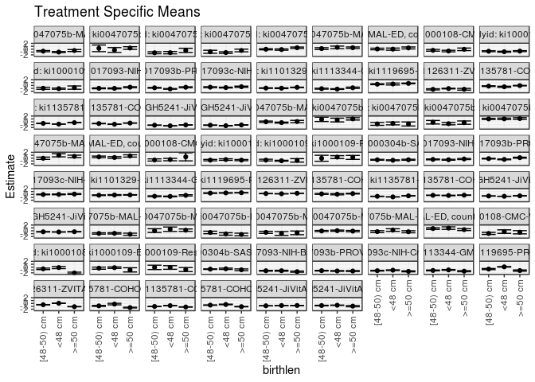

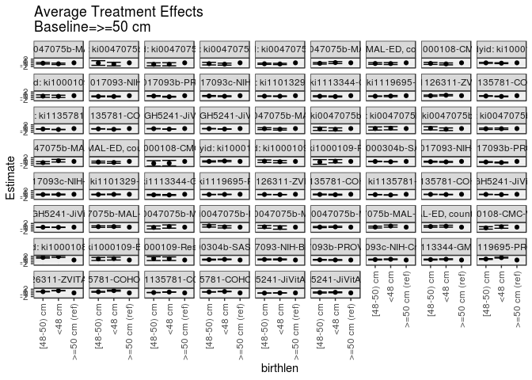

[figure not shown]

## Results Table

### Parameter: TSM

| agecat | studyid | country | intervention_level | baseline_level | estimate | ci_lower | ci_upper |
| --- | --- | --- | --- | --- | --- | --- | --- |
| Birth | ki0047075b-MAL-ED | BANGLADESH | >=50 cm | NA | -1.1990871 | -1.5683518 | -0.8298224 |
| Birth | ki0047075b-MAL-ED | BANGLADESH | <48 cm | NA | -0.8913060 | -1.1110617 | -0.6715504 |
| Birth | ki0047075b-MAL-ED | BANGLADESH | [48-50) cm | NA | -0.9274386 | -1.1603395 | -0.6945376 |
| Birth | ki0047075b-MAL-ED | BRAZIL | >=50 cm | NA | 0.2025347 | -0.2187146 | 0.6237841 |
| Birth | ki0047075b-MAL-ED | BRAZIL | <48 cm | NA | 0.5346958 | -0.2358274 | 1.3052190 |
| Birth | ki0047075b-MAL-ED | BRAZIL | [48-50) cm | NA | 0.0588243 | -0.5797706 | 0.6974193 |
| Birth | ki0047075b-MAL-ED | INDIA | >=50 cm | NA | -1.2755556 | -1.7237003 | -0.8274108 |
| Birth | ki0047075b-MAL-ED | INDIA | <48 cm | NA | -1.1033333 | -1.5325846 | -0.6740821 |
| Birth | ki0047075b-MAL-ED | INDIA | [48-50) cm | NA | -0.5900000 | -1.0271837 | -0.1528163 |
| Birth | ki0047075b-MAL-ED | NEPAL | >=50 cm | NA | -0.7287500 | -1.3613469 | -0.0961531 |
| Birth | ki0047075b-MAL-ED | NEPAL | <48 cm | NA | -0.9354545 | -1.5903488 | -0.2805603 |
| Birth | ki0047075b-MAL-ED | NEPAL | [48-50) cm | NA | -0.5514286 | -0.9073681 | -0.1954890 |
| Birth | ki0047075b-MAL-ED | PERU | >=50 cm | NA | -0.1281491 | -0.3608187 | 0.1045205 |
| Birth | ki0047075b-MAL-ED | PERU | <48 cm | NA | 0.0261582 | -0.1813829 | 0.2336993 |
| Birth | ki0047075b-MAL-ED | PERU | [48-50) cm | NA | -0.0810341 | -0.2692154 | 0.1071473 |
| Birth | ki0047075b-MAL-ED | SOUTH AFRICA | >=50 cm | NA | -0.3419855 | -0.6949385 | 0.0109674 |
| Birth | ki0047075b-MAL-ED | SOUTH AFRICA | <48 cm | NA | 0.2380363 | -0.2242490 | 0.7003215 |
| Birth | ki0047075b-MAL-ED | SOUTH AFRICA | [48-50) cm | NA | -0.3012436 | -0.6413656 | 0.0388784 |
| Birth | ki0047075b-MAL-ED | TANZANIA, UNITED REPUBLIC OF | >=50 cm | NA | 0.4012573 | 0.0854297 | 0.7170849 |
| Birth | ki0047075b-MAL-ED | TANZANIA, UNITED REPUBLIC OF | <48 cm | NA | 0.9269425 | 0.4944847 | 1.3594004 |
| Birth | ki0047075b-MAL-ED | TANZANIA, UNITED REPUBLIC OF | [48-50) cm | NA | 0.7716561 | 0.4909294 | 1.0523829 |
| Birth | ki1000108-CMC-V-BCS-2002 | INDIA | >=50 cm | NA | -0.5160136 | -1.0757370 | 0.0437099 |
| Birth | ki1000108-CMC-V-BCS-2002 | INDIA | <48 cm | NA | -0.2853428 | -0.8943410 | 0.3236555 |
| Birth | ki1000108-CMC-V-BCS-2002 | INDIA | [48-50) cm | NA | -0.9190854 | -1.2793733 | -0.5587975 |
| Birth | ki1000108-IRC | INDIA | >=50 cm | NA | -2.0433617 | -2.3335156 | -1.7532078 |
| Birth | ki1000108-IRC | INDIA | <48 cm | NA | -0.1618487 | -0.5223125 | 0.1986150 |
| Birth | ki1000108-IRC | INDIA | [48-50) cm | NA | -0.6074617 | -0.8609643 | -0.3539591 |
| Birth | ki1000109-EE | PAKISTAN | >=50 cm | NA | -0.9580209 | -1.6914170 | -0.2246248 |
| Birth | ki1000109-EE | PAKISTAN | <48 cm | NA | -0.1871056 | -0.4359008 | 0.0616896 |
| Birth | ki1000109-EE | PAKISTAN | [48-50) cm | NA | -0.3683567 | -0.7298478 | -0.0068657 |

[output cut: 177 more lines]

### Parameter: E(Y)

| agecat | studyid | country | intervention_level | baseline_level | estimate | ci_lower | ci_upper |
| --- | --- | --- | --- | --- | --- | --- | --- |
| Birth | ki0047075b-MAL-ED | BANGLADESH | NA | NA | -0.9412093 | -1.0864308 | -0.7959878 |
| Birth | ki0047075b-MAL-ED | BRAZIL | NA | NA | 0.4029032 | 0.0896793 | 0.7161272 |
| Birth | ki0047075b-MAL-ED | INDIA | NA | NA | -0.9324444 | -1.2067907 | -0.6580982 |
| Birth | ki0047075b-MAL-ED | NEPAL | NA | NA | -0.7684615 | -1.1257770 | -0.4111460 |
| Birth | ki0047075b-MAL-ED | PERU | NA | NA | -0.0520175 | -0.1725298 | 0.0684947 |
| Birth | ki0047075b-MAL-ED | SOUTH AFRICA | NA | NA | -0.1925833 | -0.4053570 | 0.0201904 |
| Birth | ki0047075b-MAL-ED | TANZANIA, UNITED REPUBLIC OF | NA | NA | 0.7624348 | 0.5710709 | 0.9537986 |
| Birth | ki1000108-CMC-V-BCS-2002 | INDIA | NA | NA | -0.4648256 | -0.7643210 | -0.1653302 |
| Birth | ki1000108-IRC | INDIA | NA | NA | -1.0105831 | -1.1973019 | -0.8238643 |
| Birth | ki1000109-EE | PAKISTAN | NA | NA | -0.3333051 | -0.5209779 | -0.1456323 |
| Birth | ki1000109-ResPak | PAKISTAN | NA | NA | -0.3663158 | -0.7677415 | 0.0351099 |
| Birth | ki1000304b-SAS-CompFeed | INDIA | NA | NA | -0.6700453 | -0.8474950 | -0.4925957 |
| Birth | ki1017093-NIH-Birth | BANGLADESH | NA | NA | -1.3499217 | -1.4444634 | -1.2553801 |
| Birth | ki1017093b-PROVIDE | BANGLADESH | NA | NA | -1.2984586 | -1.3752758 | -1.2216415 |
| Birth | ki1017093c-NIH-Crypto | BANGLADESH | NA | NA | -1.2441513 | -1.3281130 | -1.1601897 |
| Birth | ki1113344-GMS-Nepal | NEPAL | NA | NA | -1.1164431 | -1.2040134 | -1.0288728 |
| Birth | ki1119695-PROBIT | BELARUS | NA | NA | -1.1448633 | -1.3544229 | -0.9353037 |
| Birth | ki1126311-ZVITAMBO | ZIMBABWE | NA | NA | -0.5154897 | -0.5413479 | -0.4896314 |
| Birth | ki1135781-COHORTS | GUATEMALA | NA | NA | -1.0621429 | -1.1631387 | -0.9611471 |
| Birth | ki1135781-COHORTS | INDIA | NA | NA | -0.9847457 | -1.0145305 | -0.9549609 |
| Birth | ki1135781-COHORTS | PHILIPPINES | NA | NA | -0.7427251 | -0.7890855 | -0.6963647 |
| Birth | kiGH5241-JiVitA-3 | BANGLADESH | NA | NA | -0.7501567 | -0.7680049 | -0.7323085 |
| Birth | kiGH5241-JiVitA-4 | BANGLADESH | NA | NA | -0.6886269 | -0.7410452 | -0.6362086 |
| 6 months | ki0047075b-MAL-ED | BANGLADESH | NA | NA | -0.1466509 | -0.2851494 | -0.0081523 |
| 6 months | ki0047075b-MAL-ED | BRAZIL | NA | NA | 0.8577401 | 0.5390520 | 1.1764282 |
| 6 months | ki0047075b-MAL-ED | INDIA | NA | NA | -0.6644715 | -0.9812646 | -0.3476785 |
| 6 months | ki0047075b-MAL-ED | NEPAL | NA | NA | -0.4072436 | -0.7125541 | -0.1019331 |
| 6 months | ki0047075b-MAL-ED | PERU | NA | NA | 1.0551008 | 0.9144847 | 1.1957169 |
| 6 months | ki0047075b-MAL-ED | SOUTH AFRICA | NA | NA | 0.4017921 | 0.1396820 | 0.6639023 |
| 6 months | ki0047075b-MAL-ED | TANZANIA, UNITED REPUBLIC OF | NA | NA | 0.5110593 | 0.3321196 | 0.6899991 |
| 6 months | ki1000108-CMC-V-BCS-2002 | INDIA | NA | NA | -0.4931429 | -0.7890257 | -0.1972601 |
| 6 months | ki1000108-IRC | INDIA | NA | NA | -0.6409340 | -0.7788045 | -0.5030635 |
| 6 months | ki1000109-EE | PAKISTAN | NA | NA | -0.8527871 | -0.9897809 | -0.7157933 |
| 6 months | ki1000109-ResPak | PAKISTAN | NA | NA | 0.2176471 | -0.1948962 | 0.6301903 |
| 6 months | ki1000304b-SAS-CompFeed | INDIA | NA | NA | -0.6674924 | -0.8047012 | -0.5302836 |
| 6 months | ki1017093-NIH-Birth | BANGLADESH | NA | NA | -0.4636760 | -0.5549942 | -0.3723578 |
| 6 months | ki1017093b-PROVIDE | BANGLADESH | NA | NA | -0.1990907 | -0.2817968 | -0.1163845 |
| 6 months | ki1017093c-NIH-Crypto | BANGLADESH | NA | NA | 0.0297622 | -0.0491685 | 0.1086930 |
| 6 months | ki1101329-Keneba | GAMBIA | NA | NA | -0.1974657 | -0.2592285 | -0.1357029 |
| 6 months | ki1113344-GMS-Nepal | NEPAL | NA | NA | -0.6026850 | -0.6889114 | -0.5164586 |
| 6 months | ki1119695-PROBIT | BELARUS | NA | NA | 0.5792439 | 0.5193388 | 0.6391490 |
| 6 months | ki1126311-ZVITAMBO | ZIMBABWE | NA | NA | 0.3089671 | 0.2831612 | 0.3347730 |
| 6 months | ki1135781-COHORTS | GUATEMALA | NA | NA | 0.2193904 | 0.1338361 | 0.3049448 |
| 6 months | ki1135781-COHORTS | INDIA | NA | NA | -0.6983940 | -0.7275858 | -0.6692022 |
| 6 months | ki1135781-COHORTS | PHILIPPINES | NA | NA | -0.2943461 | -0.3357404 | -0.2529517 |
| 6 months | kiGH5241-JiVitA-3 | BANGLADESH | NA | NA | -0.5922919 | -0.6120107 | -0.5725732 |
| 6 months | kiGH5241-JiVitA-4 | BANGLADESH | NA | NA | -0.3757033 | -0.4185197 | -0.3328869 |
| 24 months | ki0047075b-MAL-ED | BANGLADESH | NA | NA | -0.8306417 | -0.9596160 | -0.7016674 |
| 24 months | ki0047075b-MAL-ED | BRAZIL | NA | NA | 0.2195238 | -0.1891986 | 0.6282462 |
| 24 months | ki0047075b-MAL-ED | INDIA | NA | NA | -1.1144872 | -1.3842438 | -0.8447305 |
| 24 months | ki0047075b-MAL-ED | NEPAL | NA | NA | -0.8921154 | -1.1547051 | -0.6295257 |
| 24 months | ki0047075b-MAL-ED | PERU | NA | NA | 0.0584688 | -0.0772003 | 0.1941378 |
| 24 months | ki0047075b-MAL-ED | SOUTH AFRICA | NA | NA | 0.3968681 | 0.2085799 | 0.5851564 |
| 24 months | ki0047075b-MAL-ED | TANZANIA, UNITED REPUBLIC OF | NA | NA | 0.1324519 | -0.0568428 | 0.3217466 |
| 24 months | ki1000108-CMC-V-BCS-2002 | INDIA | NA | NA | -0.4529088 | -0.6339053 | -0.2719123 |
| 24 months | ki1000108-IRC | INDIA | NA | NA | -0.7536624 | -0.8467166 | -0.6606082 |
| 24 months | ki1000109-EE | PAKISTAN | NA | NA | -0.9929439 | -1.1707082 | -0.8151796 |
| 24 months | ki1017093-NIH-Birth | BANGLADESH | NA | NA | -0.9069451 | -1.0069853 | -0.8069049 |
| 24 months | ki1017093b-PROVIDE | BANGLADESH | NA | NA | -0.8928670 | -0.9755153 | -0.8102187 |
| 24 months | ki1017093c-NIH-Crypto | BANGLADESH | NA | NA | -0.6103502 | -0.7050157 | -0.5156847 |
| 24 months | ki1101329-Keneba | GAMBIA | NA | NA | -0.7949018 | -0.8551887 | -0.7346150 |
| 24 months | ki1113344-GMS-Nepal | NEPAL | NA | NA | -1.1336900 | -1.2226955 | -1.0446844 |
| 24 months | ki1119695-PROBIT | BELARUS | NA | NA | 0.6874295 | 0.5756922 | 0.7991668 |
| 24 months | ki1126311-ZVITAMBO | ZIMBABWE | NA | NA | -1.1803052 | -1.2806626 | -1.0799477 |
| 24 months | ki1135781-COHORTS | GUATEMALA | NA | NA | -0.2016312 | -0.2740358 | -0.1292266 |
| 24 months | ki1135781-COHORTS | INDIA | NA | NA | -0.5945743 | -0.6244188 | -0.5647299 |
| 24 months | ki1135781-COHORTS | PHILIPPINES | NA | NA | -0.6103189 | -0.6471371 | -0.5735006 |
| 24 months | kiGH5241-JiVitA-3 | BANGLADESH | NA | NA | -1.2999749 | -1.3233177 | -1.2766320 |
| 24 months | kiGH5241-JiVitA-4 | BANGLADESH | NA | NA | -1.2411122 | -1.2752162 | -1.2070083 |

### Parameter: ATE

| agecat | studyid | country | intervention_level | baseline_level | estimate | ci_lower | ci_upper |
| --- | --- | --- | --- | --- | --- | --- | --- |
| Birth | ki0047075b-MAL-ED | BANGLADESH | >=50 cm | >=50 cm | 0.0000000 | 0.0000000 | 0.0000000 |
| Birth | ki0047075b-MAL-ED | BANGLADESH | <48 cm | >=50 cm | 0.3077811 | -0.1241320 | 0.7396941 |
| Birth | ki0047075b-MAL-ED | BANGLADESH | [48-50) cm | >=50 cm | 0.2716485 | -0.1650016 | 0.7082987 |
| Birth | ki0047075b-MAL-ED | BRAZIL | >=50 cm | >=50 cm | 0.0000000 | 0.0000000 | 0.0000000 |
| Birth | ki0047075b-MAL-ED | BRAZIL | <48 cm | >=50 cm | 0.3321611 | -0.5469594 | 1.2112816 |
| Birth | ki0047075b-MAL-ED | BRAZIL | [48-50) cm | >=50 cm | -0.1437104 | -0.9248935 | 0.6374727 |
| Birth | ki0047075b-MAL-ED | INDIA | >=50 cm | >=50 cm | 0.0000000 | 0.0000000 | 0.0000000 |
| Birth | ki0047075b-MAL-ED | INDIA | <48 cm | >=50 cm | 0.1722222 | -0.4483343 | 0.7927787 |
| Birth | ki0047075b-MAL-ED | INDIA | [48-50) cm | >=50 cm | 0.6855556 | 0.0594859 | 1.3116252 |
| Birth | ki0047075b-MAL-ED | NEPAL | >=50 cm | >=50 cm | 0.0000000 | 0.0000000 | 0.0000000 |
| Birth | ki0047075b-MAL-ED | NEPAL | <48 cm | >=50 cm | -0.2067045 | -1.1172348 | 0.7038257 |
| Birth | ki0047075b-MAL-ED | NEPAL | [48-50) cm | >=50 cm | 0.1773214 | -0.5485380 | 0.9031808 |
| Birth | ki0047075b-MAL-ED | PERU | >=50 cm | >=50 cm | 0.0000000 | 0.0000000 | 0.0000000 |
| Birth | ki0047075b-MAL-ED | PERU | <48 cm | >=50 cm | 0.1543073 | -0.1590189 | 0.4676336 |
| Birth | ki0047075b-MAL-ED | PERU | [48-50) cm | >=50 cm | 0.0471150 | -0.2527852 | 0.3470152 |
| Birth | ki0047075b-MAL-ED | SOUTH AFRICA | >=50 cm | >=50 cm | 0.0000000 | 0.0000000 | 0.0000000 |
| Birth | ki0047075b-MAL-ED | SOUTH AFRICA | <48 cm | >=50 cm | 0.5800218 | 0.0044758 | 1.1555678 |
| Birth | ki0047075b-MAL-ED | SOUTH AFRICA | [48-50) cm | >=50 cm | 0.0407419 | -0.4503693 | 0.5318531 |
| Birth | ki0047075b-MAL-ED | TANZANIA, UNITED REPUBLIC OF | >=50 cm | >=50 cm | 0.0000000 | 0.0000000 | 0.0000000 |
| Birth | ki0047075b-MAL-ED | TANZANIA, UNITED REPUBLIC OF | <48 cm | >=50 cm | 0.5256852 | -0.0027036 | 1.0540741 |
| Birth | ki0047075b-MAL-ED | TANZANIA, UNITED REPUBLIC OF | [48-50) cm | >=50 cm | 0.3703989 | -0.0581611 | 0.7989589 |
| Birth | ki1000108-CMC-V-BCS-2002 | INDIA | >=50 cm | >=50 cm | 0.0000000 | 0.0000000 | 0.0000000 |
| Birth | ki1000108-CMC-V-BCS-2002 | INDIA | <48 cm | >=50 cm | 0.2306708 | -0.5926324 | 1.0539739 |
| Birth | ki1000108-CMC-V-BCS-2002 | INDIA | [48-50) cm | >=50 cm | -0.4030719 | -1.0687102 | 0.2625664 |
| Birth | ki1000108-IRC | INDIA | >=50 cm | >=50 cm | 0.0000000 | 0.0000000 | 0.0000000 |
| Birth | ki1000108-IRC | INDIA | <48 cm | >=50 cm | 1.8815130 | 1.4185629 | 2.3444630 |
| Birth | ki1000108-IRC | INDIA | [48-50) cm | >=50 cm | 1.4359000 | 1.0513557 | 1.8204444 |
| Birth | ki1000109-EE | PAKISTAN | >=50 cm | >=50 cm | 0.0000000 | 0.0000000 | 0.0000000 |
| Birth | ki1000109-EE | PAKISTAN | <48 cm | >=50 cm | 0.7709153 | -0.0031179 | 1.5449486 |
| Birth | ki1000109-EE | PAKISTAN | [48-50) cm | >=50 cm | 0.5896642 | -0.2285762 | 1.4079046 |

[output cut: 177 more lines]

### Parameter: PAR

| agecat | studyid | country | intervention_level | baseline_level | estimate | ci_lower | ci_upper |
| --- | --- | --- | --- | --- | --- | --- | --- |
| Birth | ki0047075b-MAL-ED | BANGLADESH | >=50 cm | NA | 0.2578778 | -0.0743158 | 0.5900714 |
| Birth | ki0047075b-MAL-ED | BRAZIL | >=50 cm | NA | 0.2003685 | -0.1389077 | 0.5396447 |
| Birth | ki0047075b-MAL-ED | INDIA | >=50 cm | NA | 0.3431111 | -0.0993435 | 0.7855657 |
| Birth | ki0047075b-MAL-ED | NEPAL | >=50 cm | NA | -0.0397115 | -0.5703614 | 0.4909384 |
| Birth | ki0047075b-MAL-ED | PERU | >=50 cm | NA | 0.0761316 | -0.1367798 | 0.2890429 |
| Birth | ki0047075b-MAL-ED | SOUTH AFRICA | >=50 cm | NA | 0.1494022 | -0.1322948 | 0.4310992 |
| Birth | ki0047075b-MAL-ED | TANZANIA, UNITED REPUBLIC OF | >=50 cm | NA | 0.3611775 | 0.0717086 | 0.6506465 |
| Birth | ki1000108-CMC-V-BCS-2002 | INDIA | >=50 cm | NA | 0.0511880 | -0.5089636 | 0.6113396 |
| Birth | ki1000108-IRC | INDIA | >=50 cm | NA | 1.0327786 | 0.7851861 | 1.2803711 |
| Birth | ki1000109-EE | PAKISTAN | >=50 cm | NA | 0.6247158 | -0.0676988 | 1.3171304 |
| Birth | ki1000109-ResPak | PAKISTAN | >=50 cm | NA | 0.4860123 | -0.1230242 | 1.0950488 |
| Birth | ki1000304b-SAS-CompFeed | INDIA | >=50 cm | NA | 0.2757192 | 0.1125855 | 0.4388529 |
| Birth | ki1017093-NIH-Birth | BANGLADESH | >=50 cm | NA | 0.2305960 | 0.0615146 | 0.3996773 |
| Birth | ki1017093b-PROVIDE | BANGLADESH | >=50 cm | NA | 0.0643541 | -0.0775725 | 0.2062806 |
| Birth | ki1017093c-NIH-Crypto | BANGLADESH | >=50 cm | NA | 0.2364342 | 0.0860541 | 0.3868142 |
| Birth | ki1113344-GMS-Nepal | NEPAL | >=50 cm | NA | 0.2979749 | 0.1160205 | 0.4799292 |
| Birth | ki1119695-PROBIT | BELARUS | >=50 cm | NA | 0.0542477 | 0.0300116 | 0.0784838 |
| Birth | ki1126311-ZVITAMBO | ZIMBABWE | >=50 cm | NA | 0.6116377 | 0.5744729 | 0.6488026 |
| Birth | ki1135781-COHORTS | GUATEMALA | >=50 cm | NA | 0.3855981 | 0.2871468 | 0.4840494 |
| Birth | ki1135781-COHORTS | INDIA | >=50 cm | NA | 0.2517272 | 0.1987830 | 0.3046713 |
| Birth | ki1135781-COHORTS | PHILIPPINES | >=50 cm | NA | 0.3777278 | 0.3200491 | 0.4354064 |
| Birth | kiGH5241-JiVitA-3 | BANGLADESH | >=50 cm | NA | -0.0322441 | -0.0670708 | 0.0025825 |
| Birth | kiGH5241-JiVitA-4 | BANGLADESH | >=50 cm | NA | 0.2562407 | 0.0377103 | 0.4747710 |
| 6 months | ki0047075b-MAL-ED | BANGLADESH | >=50 cm | NA | -0.2167854 | -0.5812965 | 0.1477258 |
| 6 months | ki0047075b-MAL-ED | BRAZIL | >=50 cm | NA | -0.1594521 | -0.5001926 | 0.1812884 |
| 6 months | ki0047075b-MAL-ED | INDIA | >=50 cm | NA | 0.0857368 | -0.5470478 | 0.7185213 |
| 6 months | ki0047075b-MAL-ED | NEPAL | >=50 cm | NA | -0.1191186 | -0.5907705 | 0.3525333 |
| 6 months | ki0047075b-MAL-ED | PERU | >=50 cm | NA | -0.0778285 | -0.3432765 | 0.1876196 |
| 6 months | ki0047075b-MAL-ED | SOUTH AFRICA | >=50 cm | NA | -0.2060488 | -0.5609967 | 0.1488992 |
| 6 months | ki0047075b-MAL-ED | TANZANIA, UNITED REPUBLIC OF | >=50 cm | NA | -0.2469725 | -0.5777400 | 0.0837950 |
| 6 months | ki1000108-CMC-V-BCS-2002 | INDIA | >=50 cm | NA | -0.9325758 | -2.1941819 | 0.3290303 |
| 6 months | ki1000108-IRC | INDIA | >=50 cm | NA | 0.0545019 | -0.1229830 | 0.2319869 |
| 6 months | ki1000109-EE | PAKISTAN | >=50 cm | NA | -0.0758073 | -0.6357200 | 0.4841055 |
| 6 months | ki1000109-ResPak | PAKISTAN | >=50 cm | NA | -0.0249504 | -0.6819164 | 0.6320155 |
| 6 months | ki1000304b-SAS-CompFeed | INDIA | >=50 cm | NA | -0.1005526 | -0.1745387 | -0.0265664 |
| 6 months | ki1017093-NIH-Birth | BANGLADESH | >=50 cm | NA | -0.1637310 | -0.3370690 | 0.0096069 |
| 6 months | ki1017093b-PROVIDE | BANGLADESH | >=50 cm | NA | -0.3557443 | -0.5075378 | -0.2039509 |
| 6 months | ki1017093c-NIH-Crypto | BANGLADESH | >=50 cm | NA | -0.0973057 | -0.2424123 | 0.0478010 |
| 6 months | ki1101329-Keneba | GAMBIA | >=50 cm | NA | -0.0391413 | -0.1009883 | 0.0227057 |
| 6 months | ki1113344-GMS-Nepal | NEPAL | >=50 cm | NA | -0.2884139 | -0.4832887 | -0.0935391 |
| 6 months | ki1119695-PROBIT | BELARUS | >=50 cm | NA | -0.0106433 | -0.0200411 | -0.0012455 |
| 6 months | ki1126311-ZVITAMBO | ZIMBABWE | >=50 cm | NA | -0.0898053 | -0.1297043 | -0.0499064 |
| 6 months | ki1135781-COHORTS | GUATEMALA | >=50 cm | NA | -0.0666503 | -0.1506940 | 0.0173934 |
| 6 months | ki1135781-COHORTS | INDIA | >=50 cm | NA | -0.2209940 | -0.2744134 | -0.1675746 |
| 6 months | ki1135781-COHORTS | PHILIPPINES | >=50 cm | NA | -0.0469275 | -0.1006320 | 0.0067770 |
| 6 months | kiGH5241-JiVitA-3 | BANGLADESH | >=50 cm | NA | -0.1134823 | -0.1597339 | -0.0672307 |
| 6 months | kiGH5241-JiVitA-4 | BANGLADESH | >=50 cm | NA | -0.0496725 | -0.1133254 | 0.0139804 |
| 24 months | ki0047075b-MAL-ED | BANGLADESH | >=50 cm | NA | -0.3504431 | -0.6494811 | -0.0514050 |
| 24 months | ki0047075b-MAL-ED | BRAZIL | >=50 cm | NA | -0.1743012 | -0.6241620 | 0.2755596 |
| 24 months | ki0047075b-MAL-ED | INDIA | >=50 cm | NA | -0.6786538 | -1.3465606 | -0.0107471 |
| 24 months | ki0047075b-MAL-ED | NEPAL | >=50 cm | NA | -0.4314904 | -0.8201628 | -0.0428180 |
| 24 months | ki0047075b-MAL-ED | PERU | >=50 cm | NA | -0.4237054 | -0.6565037 | -0.1909072 |
| 24 months | ki0047075b-MAL-ED | SOUTH AFRICA | >=50 cm | NA | -0.0906676 | -0.3362755 | 0.1549404 |
| 24 months | ki0047075b-MAL-ED | TANZANIA, UNITED REPUBLIC OF | >=50 cm | NA | -0.2870481 | -0.5847583 | 0.0106621 |
| 24 months | ki1000108-CMC-V-BCS-2002 | INDIA | >=50 cm | NA | -0.3925027 | -0.8101028 | 0.0250975 |
| 24 months | ki1000108-IRC | INDIA | >=50 cm | NA | -0.0639811 | -0.1909474 | 0.0629852 |
| 24 months | ki1000109-EE | PAKISTAN | >=50 cm | NA | -0.2437027 | -0.8001723 | 0.3127669 |
| 24 months | ki1017093-NIH-Birth | BANGLADESH | >=50 cm | NA | -0.3039864 | -0.4625017 | -0.1454712 |
| 24 months | ki1017093b-PROVIDE | BANGLADESH | >=50 cm | NA | -0.2650850 | -0.4148203 | -0.1153497 |
| 24 months | ki1017093c-NIH-Crypto | BANGLADESH | >=50 cm | NA | -0.1763964 | -0.3422157 | -0.0105771 |
| 24 months | ki1101329-Keneba | GAMBIA | >=50 cm | NA | -0.1329029 | -0.1937799 | -0.0720259 |
| 24 months | ki1113344-GMS-Nepal | NEPAL | >=50 cm | NA | -0.3294829 | -0.5399811 | -0.1189847 |
| 24 months | ki1119695-PROBIT | BELARUS | >=50 cm | NA | -0.0253265 | -0.0428367 | -0.0078163 |
| 24 months | ki1126311-ZVITAMBO | ZIMBABWE | >=50 cm | NA | 0.1313551 | -0.1543739 | 0.4170841 |
| 24 months | ki1135781-COHORTS | GUATEMALA | >=50 cm | NA | -0.1477802 | -0.2260784 | -0.0694820 |
| 24 months | ki1135781-COHORTS | INDIA | >=50 cm | NA | -0.3019072 | -0.3572829 | -0.2465315 |
| 24 months | ki1135781-COHORTS | PHILIPPINES | >=50 cm | NA | -0.1705823 | -0.2177521 | -0.1234124 |
| 24 months | kiGH5241-JiVitA-3 | BANGLADESH | >=50 cm | NA | -0.2080256 | -0.2683192 | -0.1477321 |
| 24 months | kiGH5241-JiVitA-4 | BANGLADESH | >=50 cm | NA | -0.1472101 | -0.2036258 | -0.0907944 |